# Roteiro de Projeto 🎞️

### Visualização 🖼️

Vamos nos aprofundar na compreensão do dados que estamos manipulando.

👉 realizaremos cópia dos dados para brincar, sem afetar os dados originais.

```python
dados = df.copy()
```

#### Geográfica 🌎

Vamos aproveitar as informações geográficas (de `latitude` e `longitude`).

👉 diagrama de dispersão para visualizar os dados de todos os bairros

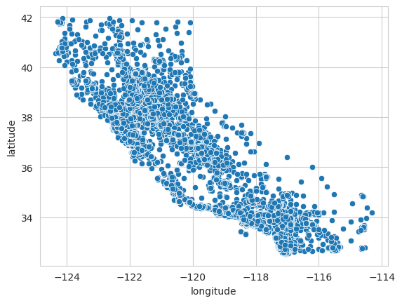

```python
with sns.axes_style("whitegrid"):
    sns.scatterplot(dados, x="longitude", y="latitude");
```

👉 Com transparência (alpha), é possível ver claramente as áreas de alta densidade.

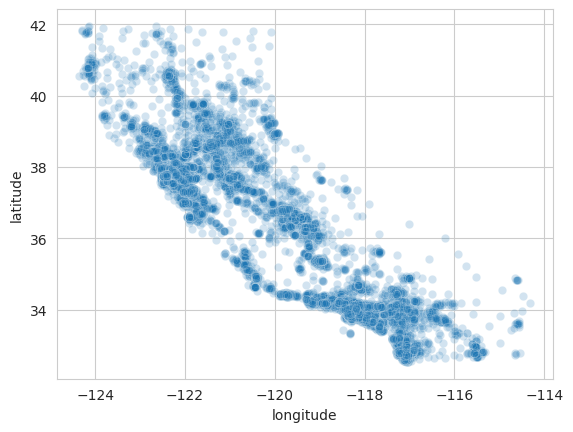

```python
with sns.axes_style("whitegrid"):
    sns.scatterplot(dados, x="longitude", y="latitude", alpha=0.2);
```

Aparentemente, os preços do setor imobiliário estão relacionados à

- localização (por exemplo, perto do oceano); e
- à densidade populacional.

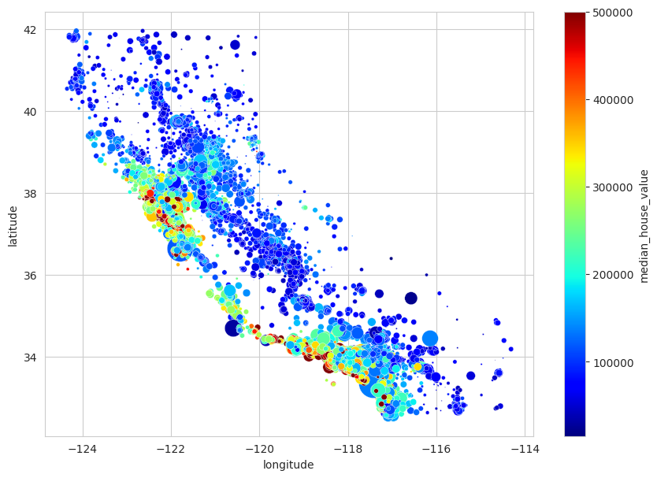

```python
plotar_colorido(dados)
```

Veja o mapa anterior sobreposto com o mapa da Califórnia.

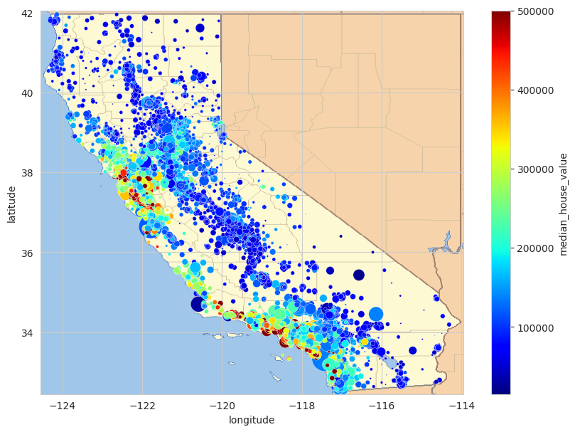

```python
plotar_colorido_com_mapa(dados)
```

#### Correlações

Podemos calcular o coeficiente de correlação padrão ($\rho$ de $Pearson$)

- entre cada par de características/variáveis.

Sabemos que $\rho \in [-1, 1]$, bem como

- $\rho$ próximo de $1$ significa que existe uma forte correlação positiva;
- $\rho$ próximo de $0$ significa que não há correlação linear;
- $\rho$ próximo de $-1$ significa que existe uma forte correlação negativa.

👉 mas não significa que temos que abrir mão de visualizar os dados.

[figure not shown]

Para calcular $\rho$, usamos o método `corr()`...

```python
dados.corr(numeric_only=True)[['median_house_value']]
```

|  | median_house_value |
| --- | --- |
| longitude | -0.045967 |
| latitude | -0.144160 |
| housing_median_age | 0.105623 |
| total_rooms | 0.134153 |
| total_bedrooms | 0.049686 |
| population | -0.024650 |
| households | 0.065843 |
| median_income | 0.688075 |
| median_house_value | 1.000000 |

... e reforçaremos os valores com um mapa de calor.

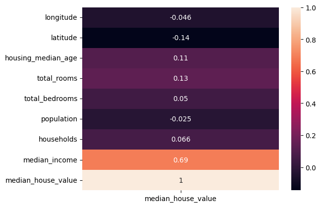

```python
sns.heatmap(dados.corr(numeric_only=True)[['median_house_value']],
            annot=True);
```

Complementarmente, podemos visualizar os diagramas de dispersão

- a cada par de características/variáveis.

👉 Escolhemos 4 características/variáveis para não poluir a figura.

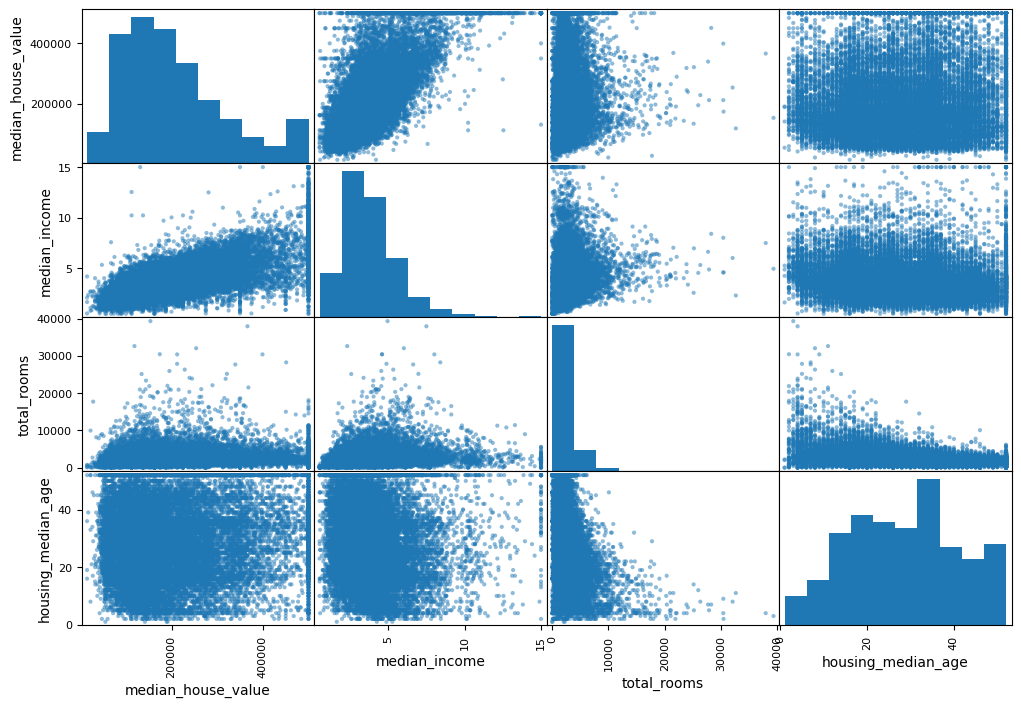

```python
from pandas.plotting import scatter_matrix

attr = ["median_house_value", "median_income", "total_rooms", "housing_median_age"]
scatter_matrix(dados[attr], figsize=(12, 8));
```

👉 Veja que as variáveis `median_house_value` e `median_income`

- apresentam correlação.

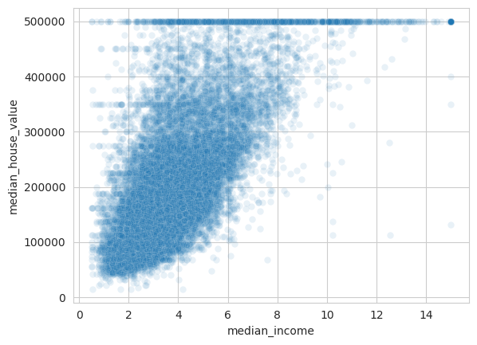

```python
with sns.axes_style("whitegrid"):
    sns.scatterplot(data=dados, x='median_income', y='median_house_value', alpha=0.1);
```

### Combinando Características/Variáveis

Podemos aperfeiçoar os nossos dados para os algoritmos de Aprendizado de Máquina.

Por exemplo,

- `total_rooms`, `total_bedrooms` e `population`
  - não parecem estar na mesma régua que
  - `median_house_value`, `median_income`, `housing_median_age`.

👉 Que tal $\frac{total\_rooms}{households}, \frac{total\_bedrooms}{total\_rooms}, \frac{population}{households}$ ?

```python
dados["rooms_per_household"] = \
    dados["total_rooms"] / dados["households"]
dados["bedrooms_per_room"] = \
    dados["total_bedrooms"] / dados["total_rooms"]
dados["population_per_household"] = \
    dados["population"] / dados["households"]
```

Vejamos como

- as novas características/variáveis `rooms_per_household`, `bedrooms_per_room` e `population_per_household`
- (em contraponto às antigas
  - características/variáveis `total_rooms`, `total_bedrooms` e `population`)
- estão correlacionadas a `median_house_value`.

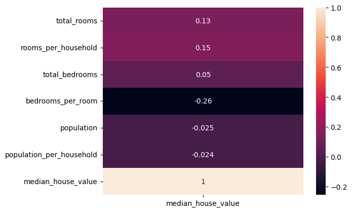

```python
attr = ["total_rooms", "rooms_per_household", "total_bedrooms",
        "bedrooms_per_room", "population", "population_per_household",
        "median_house_value"]
sns.heatmap(dados[attr].corr(numeric_only=True)[['median_house_value']],
            annot=True);
```

Complementarmente, podemos visualizar os diagramas de dispersão a cada par de características/variáveis.

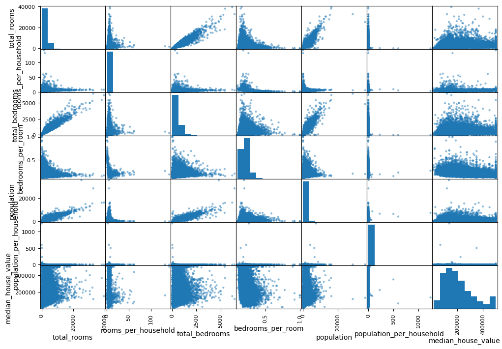

```python
from pandas.plotting import scatter_matrix

scatter_matrix(dados[attr], figsize=(12, 8));
```